# ReproResearch-Peer Assessment 1

dpd

11/29/2020

## Introduction

It is now possible to collect a large amount of data about personal movement using activity monitoring devices such as a [Fitbit](http://www.fitbit.com), [Nike Fuelband](http://www.nike.com/us/en_us/c/nikeplus-fuelband), or [Jawbone Up](https://jawbone.com/up). These type of devices are part of the “quantified self” movement – a group of enthusiasts who take measurements about themselves regularly to improve their health, to find patterns in their behavior, or because they are tech geeks. But these data remain under-utilized both because the raw data are hard to obtain and there is a lack of statistical methods and software for processing and interpreting the data.

The data in this This analysis makes use of data from a personal activity monitoring device. This device collects data at 5 minute intervals through out the day. The data consists of two months of data from an anonymous individual collected during the months of October and November, 2012 and include the number of steps taken in 5 minute intervals each day.

## Data

The data for this assignment can be downloaded from the the following web site:

- Dataset: [Activity monitoring data](https://d396qusza40orc.cloudfront.net/repdata%2Fdata%2Factivity.zip) [52K]

### Loading and preprocessing the data

Once you have downloaded and extracted the data, load it into R.

```r
library(ggplot2)
activity_data<- read.csv("activity.csv")
str(activity_data)
```

```
## 'data.frame':    17568 obs. of  3 variables:
##  $ steps   : int  NA NA NA NA NA NA NA NA NA NA ...
##  $ date    : chr  "2012-10-01" "2012-10-01" "2012-10-01" "2012-10-01" ...
##  $ interval: int  0 5 10 15 20 25 30 35 40 45 ...
```

```r
summary(activity_data)
```

```
##      steps            date              interval
##  Min.   :  0.00   Length:17568       Min.   :   0.0
##  1st Qu.:  0.00   Class :character   1st Qu.: 588.8
##  Median :  0.00   Mode  :character   Median :1177.5
##  Mean   : 37.38                      Mean   :1177.5
##  3rd Qu.: 12.00                      3rd Qu.:1766.2
##  Max.   :806.00                      Max.   :2355.0
##  NA's   :2304
```

Taking a look at the activity data using *str* and *summary* functions, we see that there are a total of 17,568 observations in this dataset and three variables; namely,

- **steps**: Number of steps taking in a 5-minute interval (note: missing values are coded as `NA`)
- **date**: The date on which the measurement was taken in YYYY-MM-DD format
- **interval**: Identifier for the 5-minute interval in which measurement was taken

### What is mean total number of steps taken per day?

First we will aggregate the data for steps per day and ignoring the missing values in the dataset.

```r
activity_stepsPD<- with(activity_data,aggregate(steps, by=list(date),sum,na.rm=TRUE))
str(activity_stepsPD)
```

```
## 'data.frame':    61 obs. of  2 variables:
##  $ Group.1: chr  "2012-10-01" "2012-10-02" "2012-10-03" "2012-10-04" ...
##  $ x      : int  0 126 11352 12116 13294 15420 11015 0 12811 9900 ...
```

```r
summary(activity_stepsPD)
```

```
##    Group.1                x
##  Length:61          Min.   :    0
##  Class :character   1st Qu.: 6778
##  Mode  :character   Median :10395
##                     Mean   : 9354
##                     3rd Qu.:12811
##                     Max.   :21194
```

By looking at the *str* and *summary* data we see that the column headings have changed and we need to re-establish them.

```r
names(activity_stepsPD)<- c("date","steps")
head(activity_stepsPD)
```

```
##         date steps
## 1 2012-10-01     0
## 2 2012-10-02   126
## 3 2012-10-03 11352
## 4 2012-10-04 12116
## 5 2012-10-05 13294
## 6 2012-10-06 15420
```

```r
summary(activity_stepsPD)
```

```
##      date               steps
##  Length:61          Min.   :    0
##  Class :character   1st Qu.: 6778
##  Mode  :character   Median :10395
##                     Mean   : 9354
##                     3rd Qu.:12811
##                     Max.   :21194
```

A histogram of the total number of steps taken each day

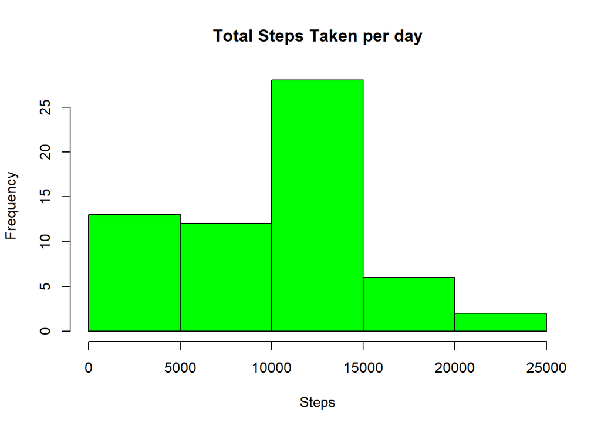

```r
hist(activity_stepsPD$steps,
     main="Total Steps Taken per day",
     xlab="Steps",col="green")
```

To Calculate and report the **mean** and **median** total number of steps taken per day…

The *summary* function we used to view the data has already provided us with the mean and median. However, if you specifically want to call the mean and median, use the following code:

```r
stepPD_mean<-mean(activity_stepsPD$steps)
stepPD_mean
```

```
## [1] 9354.23
```

```r
stepPD_median<-median(activity_stepsPD$steps)
stepPD_median
```

```
## [1] 10395
```

```r
summary(activity_stepsPD)
```

```
##      date               steps
##  Length:61          Min.   :    0
##  Class :character   1st Qu.: 6778
##  Mode  :character   Median :10395
##                     Mean   : 9354
##                     3rd Qu.:12811
##                     Max.   :21194
```

### What is the average daily activity pattern?

Using a time series plot (i.e. `type = "l"`) of the 5-minute interval (x-axis) and the average number of steps taken, averaged across all days (y-axis) you see the average daily activity pattern.

```r
activity_stepsPT<- with(activity_data,aggregate(steps, by=list(interval),mean,na.rm=TRUE))
str(activity_stepsPT)
```

```
## 'data.frame':    288 obs. of  2 variables:
##  $ Group.1: int  0 5 10 15 20 25 30 35 40 45 ...
##  $ x      : num  1.717 0.3396 0.1321 0.1509 0.0755 ...
```

```r
summary(activity_stepsPT)
```

```
##     Group.1             x
##  Min.   :   0.0   Min.   :  0.000
##  1st Qu.: 588.8   1st Qu.:  2.486
##  Median :1177.5   Median : 34.113
##  Mean   :1177.5   Mean   : 37.383
##  3rd Qu.:1766.2   3rd Qu.: 52.835
##  Max.   :2355.0   Max.   :206.170
```

```r
names(activity_stepsPT)<- c("interval","MeanSteps")
head(activity_stepsPT)
```

```
##   interval MeanSteps
## 1        0 1.7169811
## 2        5 0.3396226
## 3       10 0.1320755
## 4       15 0.1509434
## 5       20 0.0754717
## 6       25 2.0943396
```

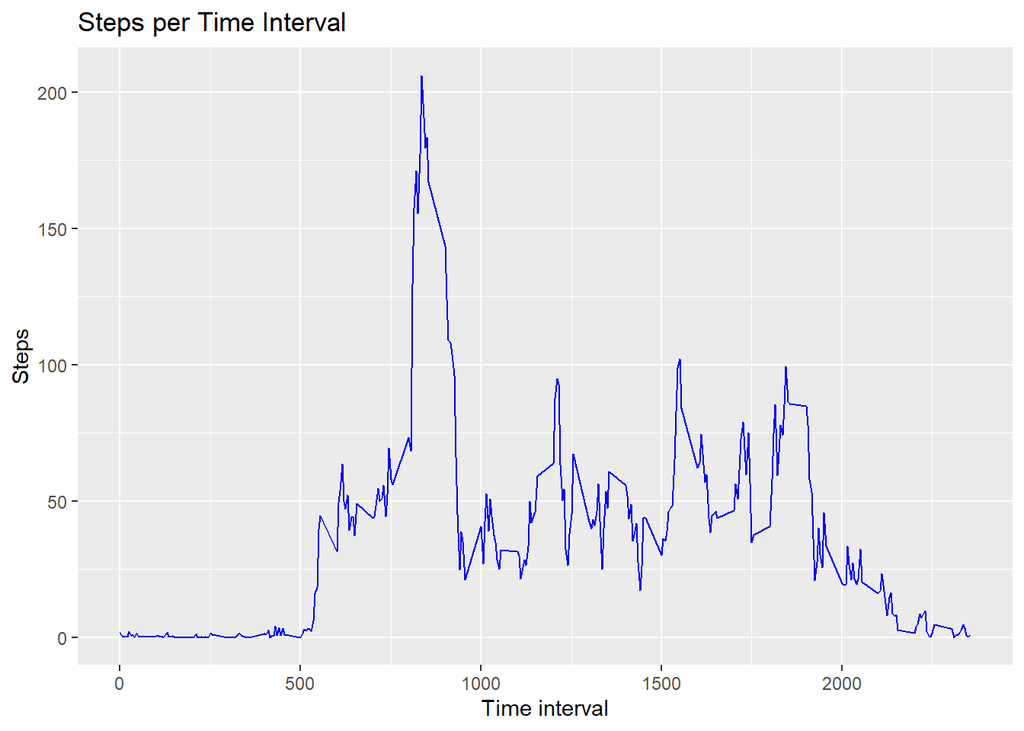

```r
library(ggplot2)
ggplot(activity_stepsPT, aes(interval, MeanSteps))+
geom_line(col="blue")+
        ggtitle("Average steps per interval")+
        xlab("Time interval")+ylab("Steps")+
        ggtitle("Steps per Time Interval")
```

The interval, on average across all the days in the dataset, associated with the maximum number of steps is 835, with ~206 steps. See code and output below.

```r
max_stepsI<- activity_stepsPT[which.max(activity_stepsPT$MeanSteps),]
max_stepsI
```

```
##     interval MeanSteps
## 104      835  206.1698
```

### Imputing missing values

There are a number of days/intervals where there are missing values (coded as `NA`). The presence of missing days may introduce bias into some calculations or summaries of the data.

In our dataset there are **2304** rows with missing data (“NA”)

There are a number of ways to determine the number of missing values. We have already seen the most common using the summary function.

```r
summary(activity_data)
```

```
##      steps            date              interval
##  Min.   :  0.00   Length:17568       Min.   :   0.0
##  1st Qu.:  0.00   Class :character   1st Qu.: 588.8
##  Median :  0.00   Mode  :character   Median :1177.5
##  Mean   : 37.38                      Mean   :1177.5
##  3rd Qu.: 12.00                      3rd Qu.:1766.2
##  Max.   :806.00                      Max.   :2355.0
##  NA's   :2304
```

You can also use the sum function with the is.na function.

```r
sum(is.na(activity_data$steps))
```

```
## [1] 2304
```

You could also create a variable (‘missingVals’) looking for complete cases and sum the number of records equal to TRUE

```r
missingVals<- !complete.cases(activity_data)
sum(missingVals==TRUE)
```

```
## [1] 2304
```

```r
library(dplyr)
imp_data <- activity_data %>%
  mutate(
    steps = case_when(
      is.na(steps) ~ activity_stepsPT$MeanSteps[match(activity_data$interval, activity_stepsPT$interval)],
      TRUE ~ as.numeric(steps)
    ))
```

Verifying that there are no “NA” values

```r
sum(is.na(imp_data))
```

```
## [1] 0
```

To see a histogram of the total number of steps taken each day with the “complete” dataset (’imp_data) we firt need to aggregate the data by date. `

```r
imp_data_stepsPD<- with(imp_data,aggregate(steps, by=list(date),sum,header=TRUE))
names(imp_data_stepsPD)<- c("date","steps")
```

A simple histogram then is produced using this code

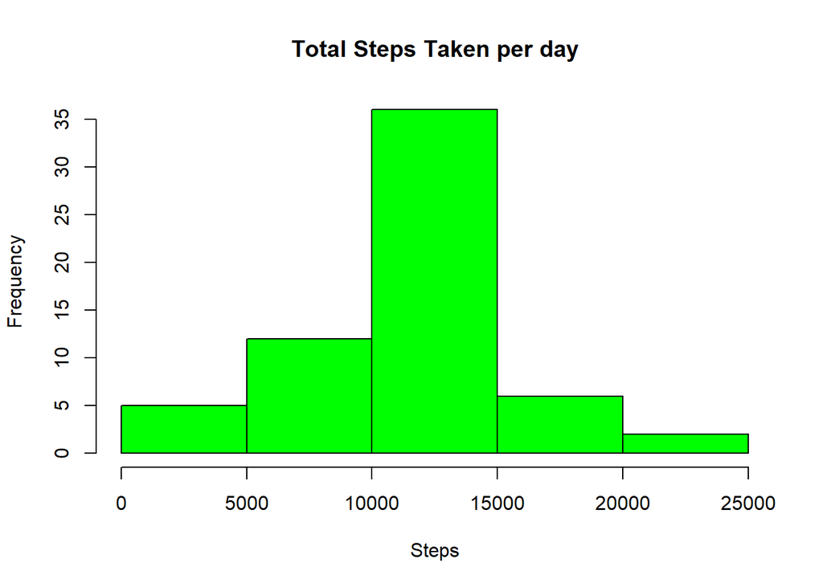

```r
hist(imp_data_stepsPD$steps,
     main="Total Steps Taken per day",
     xlab="Steps",col="green")
```

The **mean** and **median** total number of steps taken per day of the ‘imp_data’ are as follows:

```r
imp_mean<-mean(imp_data_stepsPD$steps)
## Mean
imp_mean
```

```
## [1] 10767.19
```

```r
imp_median<-median(imp_data_stepsPD$steps)
## Median
imp_median
```

```
## [1] 10767.19
```

These values differ from the estimates from the original data. The impact of imputing missing data on the estimates of the total daily number of steps can be seen when you compare the means and medians of the two data sets.

```r
dif_mean<- imp_mean - stepPD_mean
dif_mean
```

```
## [1] 1412.959
```

```r
dif_median<- imp_median - stepPD_median
dif_median
```

```
## [1] 372.1887
```

## Are there differences in activity patterns between weekdays and weekends?

To analyze if there are differences in activity patterns between weekdays and weekends, using the “complete” dataste (‘imp_data’) we need to create a new factor variable in the dataset with two levels – “weekday” and “weekend” indicating whether a given date is a weekday or weekend day.

First let’s add a duplicate column of the “date” column and call this column WD_WE for weekday_weekend.

```r
imp_data_WD_WE<- imp_data %>%
  mutate(WD_WE = date)
```

Next we need to determine if the date is a weekend day or weekday day and label accordingly in the WD_WE column.

```r
imp_data_WD_WE$WD_WE <- ifelse(weekdays(as.Date(imp_data_WD_WE$WD_WE)) == "Saturday" | weekdays(as.Date(imp_data_WD_WE$WD_WE)) == "Sunday", "weekend", "weekday")
```

Now we need to aggregate the steps using the WD_WE and interval data.

```r
week_end_day <- aggregate(steps ~ WD_WE+interval, data=imp_data_WD_WE, sum)
```

[figure not shown]

```r
library(ggplot2)
ggplot(week_end_day, aes(interval, steps)) +
  geom_line() +
  facet_wrap(~WD_WE, nrow = 2) +
  xlab("5 minuter intervals") +
  ylab("Average number of steps taken")+
  ggtitle("Weekday vs Weekend -- steps by interval")
```